# Regularization with `glmnet`

Adi Sarid

July 2019

## Read the dataset

We’re returning to our Alchohol consumption data set (for details about this data set see `01-linear_regression_example1.Rmd`).

Lets see the simple linear regression model again, we’re using `log(gdp2010)` which is a better predictor than `gdp2010`.

```r
alchohol <- read_csv("https://github.com/sarid-ins/statistical_learning_course/raw/master/datasets/alchohol_consumption/alchohol_consumption_ready.csv") %>%
  mutate(asia = ifelse(Continent_Name == "Asia", 1, 0),
         europe = ifelse(Continent_Name == "Europe", 1, 0),
         south_america = ifelse(Continent_Name == "South America", 1, 0),
         north_america = ifelse(Continent_Name == "North America", 1, 0),
         africa = ifelse(Continent_Name == "Africa", 1, 0)) %>%
  select(ends_with("servings"), gdp2010, asia:africa) %>%
  mutate(log_gdp2010 = log(gdp2010)) %>%
  select(-gdp2010)
nominal_beer_lm <- lm(formula = beer_servings ~ .,
                      data = alchohol)

summary(nominal_beer_lm)
```

```
##
## Call:
## lm(formula = beer_servings ~ ., data = alchohol)
##
## Residuals:
##     Min      1Q  Median      3Q     Max
## -155.21  -36.78  -11.75   32.44  288.94
##
## Coefficients:
##                   Estimate Std. Error t value Pr(>|t|)
## (Intercept)     -125.59204   48.10204  -2.611  0.00987 **
## spirit_servings    0.35739    0.07551   4.733 4.75e-06 ***
## wine_servings      0.28058    0.09439   2.973  0.00340 **
## asia             -60.70701   23.03463  -2.635  0.00921 **
## europe             4.88328   25.77058   0.189  0.84994
## south_america     23.89559   29.97037   0.797  0.42643
## north_america      5.11971   27.74159   0.185  0.85381
## africa            13.11215   23.14918   0.566  0.57188
## log_gdp2010       23.09882    5.34337   4.323 2.66e-05 ***
## ---
## Signif. codes:  0 '***' 0.001 '**' 0.01 '*' 0.05 '.' 0.1 ' ' 1
##
## Residual standard error: 71.11 on 164 degrees of freedom
## Multiple R-squared:  0.5433, Adjusted R-squared:  0.521
## F-statistic: 24.39 on 8 and 164 DF,  p-value: < 2.2e-16
```

## The Lasso ($L_1$ regularization)

Let’s see what the Lasso provides compared to `lm`.

```r
#install.packages("glmnet")
suppressWarnings(suppressMessages(library(glmnet)))

# test a few penalties
lambda_vals <- 10^seq(3, -2, by = -.1) # <- needs to be in decreasing order for optimization
# multiple values to be used in cross-validation

# prep a matrix for glmnet
x_mat <- alchohol %>%
  select(-beer_servings) %>%
  as.matrix()

beer_lasso <- glmnet(x = x_mat,
                     y = alchohol$beer_servings,
                     alpha = 1,
                     lambda = lambda_vals)

summary(beer_lasso)
```

```
##           Length Class     Mode
## a0         51    -none-    numeric
## beta      408    dgCMatrix S4
## df         51    -none-    numeric
## dim         2    -none-    numeric
## lambda     51    -none-    numeric
## dev.ratio  51    -none-    numeric
## nulldev     1    -none-    numeric
## npasses     1    -none-    numeric
## jerr        1    -none-    numeric
## offset      1    -none-    logical
## call        5    -none-    call
## nobs        1    -none-    numeric
```

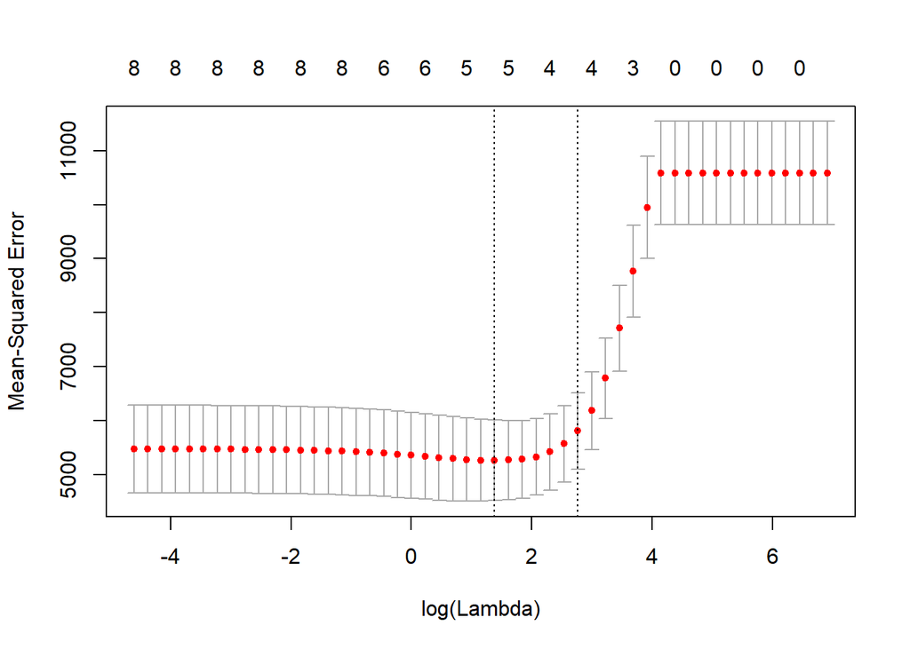

```r
beer_lasso_cv <- cv.glmnet(
  x = x_mat,
  y = alchohol$beer_servings,
  alpha = 1,
  lambda = lambda_vals
)

plot(beer_lasso_cv)
```

```r
# the optimal lambda is here (brings mse to minimum)
optimal_lambda <- beer_lasso_cv$lambda.min
optimal_lambda
```

```
## [1] 3.981072
```

```r
# let's compute the predictions with the optimal lambda, in this case the 16th model in the series
beer_lasso_pred <- predict(beer_lasso_cv$glmnet.fit, newx = x_mat)[,16]

# we can also see the beta coefficients and compare some of the selected models.
# s15 is the optimal model in terms of mse:
beer_lasso_cv$glmnet.fit$beta[, c(1, 14, 16, 20, 40, 51)]
```

```
## 8 x 6 sparse Matrix of class "dgCMatrix"
##                 s0        s13         s15         s19         s39
## spirit_servings  . .           0.09496289   0.2490560   0.3572221
## wine_servings    . 0.04943525  0.18072416   0.2399348   0.2804863
## asia             . .          -3.35347527 -43.3227872 -62.4335026
## europe           . .           .            .           2.9198856
## south_america    . .           .            .          21.5102398
## north_america    . .           .            .           2.8492244
## africa           . .           .            .          10.8064551
## log_gdp2010      . 2.23369584  8.67183358  16.7157322  22.9776338
##                         s50
## spirit_servings   0.3574849
## wine_servings     0.2806085
## asia            -60.9904697
## europe            4.5727168
## south_america    23.5609932
## north_america     4.7927835
## africa           12.8107014
## log_gdp2010      23.0926740
```

## The Ridge ($L_2$ regularization)

We use the same function to run a ridge regression. The only difference is in the $\alpha$ argument of the function.

The $\alpha$ balances the rigde versus lasso, so $\alpha=1$ is lasso, $\alpha=0$ is ridge. Any other value is a mix between the two.

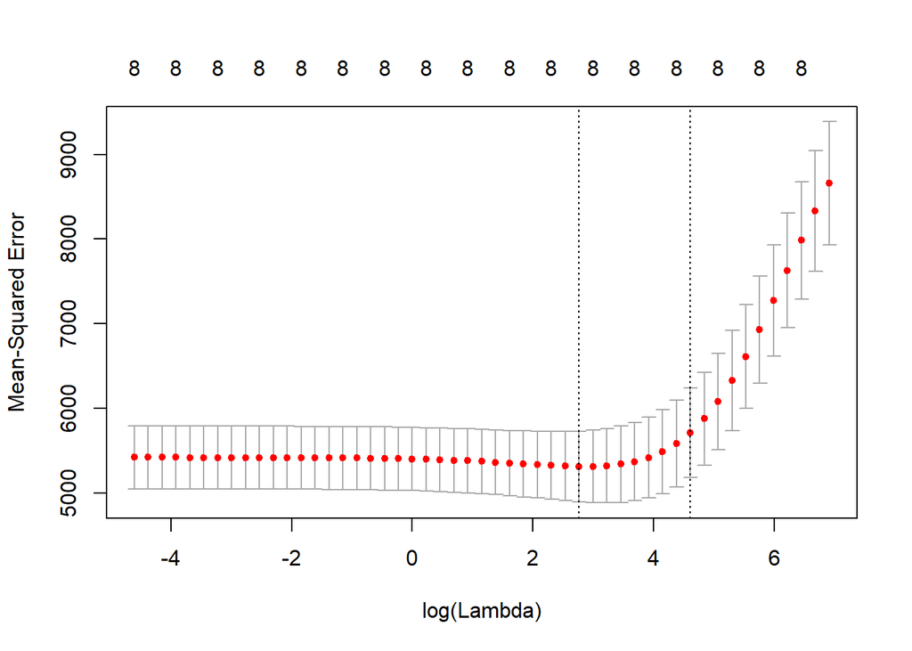

```r
beer_ridge_cv <- cv.glmnet(
  x = x_mat,
  y = alchohol$beer_servings,
  alpha = 0,
  lambda = lambda_vals
)

plot(beer_ridge_cv)
```

```r
# the optimal lambda is here (brings mse to minimum)
optimal_lambda <- beer_ridge_cv$lambda.min
optimal_lambda
```

```
## [1] 15.84893
```

The optimal $\lambda$ in the ridge regression case is entirely different, $\lambda=15.85$. Note that for all $\lambda$ values in the ridge regression, all 8 coefficients appear.